# Question 1 - Can we predict the state by the mental health of a person?

Group Rimundo Lulio

```r
# Lee las líneas del archivo
lineas <- readLines('FPdata.csv')

# Elimina las comillas al principio y al final de cada línea.
lineas <- gsub("^\"", "", lineas)
lineas <- gsub("\"$", "", lineas)
# Cambia las lineas con doble comilla ("") por una sola (")
lineas <- gsub("\"\"", "\"", lineas)

# Crea un nuevo archivo temporal sin las comillas al principio y al final
# NO SE SI SE PUEDE HACER DE OTRA FORMA SIN EL ARCHIVO TEMPORAL
archivo_temporal <- tempfile(fileext = ".csv")
writeLines(lineas, archivo_temporal)

# Lee el archivo CSV sin comillas al principio y al final
df <- read.csv(file = archivo_temporal, header = TRUE, stringsAsFactors = TRUE, quote = "\"")

cdf <- read.csv('FPdata_CLEAN.csv')
```

## Mental health dataset

To try to answer this question we are going to take a few variables of the complete dataset that are related to mental health and build some classification models with the techniques studied along the course. These variables are:

- State: this is the state of residence of the people. It will be our ground truth. [chr]
- MentalHealthDays: It is the mental health state of the people, which includes stress, depression, and problems with emotions, on the last 30 days [num: 0, 1, …, 30]
- SleepHours: On average, how many hours of sleep does the people get [num: 0, 1, …, 24]
- HadDepressiveDissorder: If the subject ever had depressive disorder (including depression, major depression, dysthymia, or minor depression) [chr: No, Yes]
- DifficultyConcentrating: If because of a physical, mental, or emotional condition, the subject has serious difficulty concentrating, remembering, or making decisions. [chr: No , Yes]
- HighRiskLastYear: If the subject has injected any drug other than those prescribed for you in the past year. If has been treated for a sexually transmitted disease or STD in the past year or if has given or received money or drugs in exchange for sex in the past year. This one has been chosen since we consider that the consequence of having suffered of this problem, can cause some kind of mental harm or trauma. [chr: No, Yes]

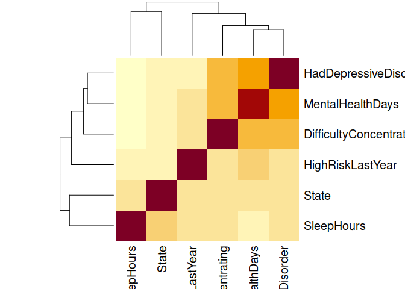

```r
mental_health_df = cdf[c("State","HadDepressiveDisorder","DifficultyConcentrating","MentalHealthDays","HighRiskLastYear","SleepHours")]
# Supongamos que mental_health_df es tu data frame
# Elimina todas las filas donde mental_health_df$State es igual a -1
mental_health_df <- mental_health_df[mental_health_df$State != -1, ]
mental_health_df <- mental_health_df[order(mental_health_df$State), ]

heatmap(cor(mental_health_df))
```

To try to achieve some good results we are going to use as models: decision tree implementations, K-Nearest Neighbours and Naive Bayes algorithm.

First of all, we are going to see how the data performs only with the general data cleansing applied to the dataset.

To get a good accuaracy we are goint to split the mental_health_df into training and a testing sets with train/test ratio of 70% since we consider the dataset is large enough to get a good training with this percentage of the data.

```r
get_state_label = function(id){
  state_labels = na.omit(unique(df$State))
  state_ids = na.omit(unique(mental_health_df$State))
  return(state_labels[id])
}

mental_health_df$State_label <- get_state_label(mental_health_df$State)
```

```r
library(caTools)
split <- sample.split(mental_health_df$State, SplitRatio = 0.7)
train_data <- subset(mental_health_df, split == TRUE)
test_data <- subset(mental_health_df, split == FALSE)
```

###Decision Tree (CART)

```r
# Load required packages
#install.packages(c("rpart"))
library(rpart)

# Build a decision tree

#Set 1
tree_model <- rpart(
  State ~ HadDepressiveDisorder + SleepHours + DifficultyConcentrating + HighRiskLastYear + MentalHealthDays,
  data = train_data,
  method = "class",
  control = rpart.control(cp=1e-7)
)
```

We have trained a decision tree (CART) model and after that we are going to get the best tree and prune it.

```r
bestcp <- tree_model$cptable[which.min(tree_model$cptable[,"xerror"]),"CP"]
tree_model <- prune(tree_model, cp = bestcp)

# Make predictions on the trained data
train_pred_rpart <- predict(tree_model, train_data[, c("MentalHealthDays","SleepHours", "HadDepressiveDisorder", "DifficultyConcentrating", "HighRiskLastYear" )], type = 'class')

# Get the accuracy of the model on the test set.
accuracy_rpart <- sum(train_pred_rpart == train_data$State) / nrow(train_data)

# Print the accuracy
print(paste('Accuracy for training data using rpart is found to be', round(accuracy_rpart * 100, 2), '%'))
```

```
## [1] "Accuracy for training data using rpart is found to be 5.94 %"
```

After making the predictions on the decision tree we can see that we only are able to get a 6% of accuaracy.

### K-NN

```r
# Commented to knit
# library(class)
# library(ggplot2)
# library(knitr)
# library(gmodels)
# distance_func <- function(x, y) sum(x != y)
#
# knn_model <- knn(train =  train_data[,c("MentalHealthDays","SleepHours", "HadDepressiveDisorder", "DifficultyConcentrating", "HighRiskLastYear" )], test = test_data[, c("MentalHealthDays","SleepHours", "HadDepressiveDisorder", "DifficultyConcentrating", "HighRiskLastYear" )], train_data$State, k = 7)
# test_accuracy <- sum(knn_model == test_data$State) / nrow(test_data)
#
#
#
# cat("Training Set1 Accuracy:", test_accuracy, "\n")
```

For the K-NN model we can’t get any results since the model can’t finish due to have too many ties. We believe that this is caused because most of the variables are binary producing a lot of ties in distance. In the future we are going to try to avoid it.

### Naive Bayes

```r
library(e1071)


# Crear un modelo de Naive Bayes
naive_bayes_model <- naiveBayes( y = train_data$State ,x =  train_data[,c("MentalHealthDays","SleepHours", "HadDepressiveDisorder", "DifficultyConcentrating", "HighRiskLastYear" )] , data = train_data)

# Realizar predicciones en el conjunto de prueba
predictions <- predict(naive_bayes_model, test_data)
conf_matrix<-as.matrix(table(test_data$State, predictions))
correct <-sum(diag(conf_matrix))
n<-length(test_data$State)
accuracy <-correct/n
accuracy
```

```
## [1] 0.05423506
```

With the Naive Bayes model we also get a very low accuracy, only 5%.

## Data processing

We have seen that with the mental health df as it comes from the whole dataset, we can’t get any results. We believe that this is mainly because we have too many classes to predict and because of the nature of the data. The decisions that we have made to try to avoid this are:

### Reducing labels

First of all to reduce the number of labels to predict, we have made some research (https://en.wikipedia.org/wiki/List_of_states_and_territories_of_the_United_States_by_population_density) and based on the USA census of 2020 we have divided the States into density of population, to be exact by number of people by km2. The clasifications are:

- More than 100 people by km2
- Between 100 and 43 people by km2
- Between 43 and 20 pepple by km2
- Less than 20 people by km2

We have chosen this classification since we hope that 4 labels are few enough to get a good classifier. Another reason is that with this classification we get 4 balanced classes to predict, avoiding making a model better at predicting some class.

```r
above100 <- c("District of Columbia", "New Jersey", "Rhode Island", "Puerto Rico","Massachusetts", "Connecticut",
               "Guam", "Virgin Islands", "Maryland", "Delaware", "New York", "Florida", "Pennsylvania", "Ohio")
between100to43 <- c("California", "Illinois", "Hawaii", "Virginia","North Carolina", "Indiana","Georgia",
                    "Michigan","South Carolina", "Tennessee","New Hampshire","Washington" , "Kentucky")
between43to20 <- c("Texas", "Wisconsin","Louisiana","Alabama","Missouri","West Virginia", "Minnesota","Vermont","Mississippi","Arizona","Arkansas","Oklahoma","Iowa")

under20 <-c("Colorado","Maine","Oregon","Utah","Kansas","Nevada","Nebraska", "Idaho", "New Mexico", "South Dakota","North Dakota", "Montana", "Wyoming", "Alaska")
```

```r
mental_health_df$density_class <- ifelse(is.element(mental_health_df$State_label, above100),1,ifelse(is.element(mental_health_df$State_label,between100to43),2,ifelse(is.element(mental_health_df$State_label,between43to20),3,ifelse(is.element(mental_health_df$State_label,under20),4,5))))
table(mental_health_df$density_class)
```

```
##
##      1      2      3      4
##  99442 106007 109998 110596
```

```r
mental_health_df$density_class_label <- ifelse(mental_health_df$density_class == 1, 'Above100',ifelse(mental_health_df$density_class == 2,'Between100and43', ifelse(mental_health_df$density_class == 3, 'Between43and20','Under20'   )))
```

```r
summary(mental_health_df)
```

```
##      State      HadDepressiveDisorder DifficultyConcentrating MentalHealthDays
##  Min.   : 1.0   Min.   :0.0000        Min.   :0.0000          Min.   :0.0000
##  1st Qu.:16.0   1st Qu.:0.0000        1st Qu.:0.0000          1st Qu.:0.0000
##  Median :27.0   Median :0.0000        Median :0.0000          Median :0.0000
##  Mean   :28.4   Mean   :0.1981        Mean   :0.1085          Mean   :0.1386
##  3rd Qu.:43.0   3rd Qu.:0.0000        3rd Qu.:0.0000          3rd Qu.:0.1333
##  Max.   :54.0   Max.   :1.0000        Max.   :1.0000          Max.   :1.0000
##
##  HighRiskLastYear    SleepHours             State_label     density_class
##  Min.   :0.00000   Min.   :0.0000   Wyoming       : 25186   Min.   :1.000
##  1st Qu.:0.00000   1st Qu.:0.2174   North Carolina: 17230   1st Qu.:2.000
##  Median :0.00000   Median :0.2609   Mississippi   : 16136   Median :3.000
##  Mean   :0.03821   Mean   :0.2622   Massachusetts : 15740   Mean   :2.544
##  3rd Qu.:0.00000   3rd Qu.:0.3043   Oklahoma      : 15437   3rd Qu.:4.000
##  Max.   :1.00000   Max.   :1.0000   Vermont       : 13545   Max.   :4.000
##                                     (Other)       :322769
##  density_class_label
##  Length:426043
##  Class :character
##  Mode  :character
##
##
##
##
```

```r
str(mental_health_df)
```

```
## 'data.frame':    426043 obs. of  9 variables:
##  $ State                  : int  1 1 1 1 1 1 1 1 1 1 ...
##  $ HadDepressiveDisorder  : int  0 0 0 0 0 0 0 0 0 0 ...
##  $ DifficultyConcentrating: int  0 0 0 0 0 0 0 0 0 0 ...
##  $ MentalHealthDays       : num  0 0 0.1 0 0 0 0 0 0 0 ...
##  $ HighRiskLastYear       : int  0 0 0 0 0 0 0 0 0 0 ...
##  $ SleepHours             : num  0.304 0.217 0.174 0.261 0.348 ...
##  $ State_label            : Factor w/ 54 levels "Alabama","Alaska",..: 1 1 1 1 1 1 1 1 1 1 ...
##  $ density_class          : num  3 3 3 3 3 3 3 3 3 3 ...
##  $ density_class_label    : chr  "Between43and20" "Between43and20" "Between43and20" "Between43and20" ...
```

The other technique to improve the nature of the data is to normalize it so all the values are between 0 and 1. Normalizing the data in a classification model is beneficial because it ensures that features with different scales contribute equally to the model, preventing dominance by variables with larger magnitudes.

```r
normalize <- function(x) {
  return ((x - min(x)) / (max(x) - min(x)))
}
```

```r
mental_health_df$density_class_label <- ifelse(mental_health_df$density_class == 1 , 'MT100', ifelse(mental_health_df$density_class ==2,'B100TO43',ifelse(mental_health_df$density_class ==3,'B43TO20','U20')))
mental_health_df$density_class_label <- as.factor(mental_health_df$density_class_label)
```

```r
table(mental_health_df$density_class_label)
```

```
##
## B100TO43  B43TO20    MT100      U20
##   106007   109998    99442   110596
```

```r
mental_health_df_normalized <-as.data.frame(lapply(mental_health_df[c("density_class","HadDepressiveDisorder","DifficultyConcentrating","MentalHealthDays","HighRiskLastYear","SleepHours")], normalize))
mental_health_df_normalized$density_class_label <- mental_health_df$density_class_label
```

```r
table(mental_health_df_normalized$density_class_label)
```

```
##
## B100TO43  B43TO20    MT100      U20
##   106007   109998    99442   110596
```

After that we split our data again.

```r
library(caTools)

split <- sample.split(mental_health_df_normalized$density_class, SplitRatio = 0.7)
train_data <- subset(mental_health_df_normalized, split == TRUE)
test_data <- subset(mental_health_df_normalized, split == FALSE)
```

Let’s see how our models have improved:

### Decision Tree (CART)

```r
# Load required packages
#install.packages(c("rpart"))
library(rpart)

# Build a decision tree

#Set 1
tree_model <- rpart(
  density_class_label ~ HadDepressiveDisorder + SleepHours + DifficultyConcentrating + HighRiskLastYear + MentalHealthDays,
  data = train_data,
  method = "class",
  control = rpart.control(cp=1e-6)
)


bestcp <- tree_model$cptable[which.min(tree_model$cptable[,"xerror"]),"CP"]
tree_model <- prune(tree_model, cp = bestcp)

# Make predictions on the trained data
train_pred_rpart <- predict(tree_model, train_data[, c("MentalHealthDays","SleepHours", "HadDepressiveDisorder", "DifficultyConcentrating", "HighRiskLastYear" )], type = 'class')

# Get the accuracy of the model on the test set.
accuracy_rpart <- sum(train_pred_rpart == train_data$density_class_label) / nrow(train_data)

# Print the accuracy
print(paste('Accuracy for training data using rpart is found to be', accuracy_rpart * 100, '%'))
```

```
## [1] "Accuracy for training data using rpart is found to be 26.525835764343 %"
```

```r
library(RWeka)
library(party)
library(partykit)
library(FSelector)

id3 <- J48(density_class_label ~ HadDepressiveDisorder + SleepHours + DifficultyConcentrating + HighRiskLastYear + MentalHealthDays, data = train_data)
summary(id3)
```

```
##
## === Summary ===
##
## Correctly Classified Instances       79988               26.8209 %
## Incorrectly Classified Instances    218242               73.1791 %
## Kappa statistic                          0.0133
## Mean absolute error                      0.3743
## Root mean squared error                  0.4326
## Relative absolute error                 99.8645 %
## Root relative squared error             99.9322 %
## Total Number of Instances           298230
##
## === Confusion Matrix ===
##
##      a     b     c     d   <-- classified as
##   3806 37081   198 33120 |     a = B100TO43
##   3259 40239   210 33291 |     b = B43TO20
##   2965 35640   338 30666 |     c = MT100
##   3335 38281   196 35605 |     d = U20
```

```r
predictions <- predict(id3, test_data)
conf_matrix<-as.matrix(table(test_data$density_class_label, predictions))
conf_matrix
```

```
##           predictions
##            B100TO43 B43TO20 MT100   U20
##   B100TO43     1485   15989    97 14231
##   B43TO20      1528   16969    98 14404
##   MT100        1262   15155    81 13335
##   U20          1450   16643    97 14989
```

```r
correct <-sum(diag(conf_matrix))
n<-length(test_data$density_class_label)
accuracy <-correct/n
accuracy
```

```
## [1] 0.2622894
```

## K-NN

```r
# Commented to knit
# library(class)
# library(ggplot2)
# library(knitr)
# library(gmodels)
# distance_func <- function(x, y) sum(x != y)
#
# knn_model <- knn(train =  train_data[,c("MentalHealthDays","SleepHours", "HadDepressiveDisorder", "DifficultyConcentrating", "HighRiskLastYear" )], test = test_data[, c("MentalHealthDays","SleepHours", "HadDepressiveDisorder", "DifficultyConcentrating", "HighRiskLastYear" )], train_data$density_class, k = 7)
# test_accuracy <- sum(knn_model == test_data$density_class) / nrow(test_data)
#
#
# cat("Training Set1 Accuracy:", test_accuracy, "\n")
#
```

We still get too many ties.

### Naive Bayes

```r
library(e1071)


# Crear un modelo de Naive Bayes

naive_bayes_model <- naiveBayes( y = train_data$density_class_label ,x =  train_data[,c("MentalHealthDays","SleepHours", "HadDepressiveDisorder", "DifficultyConcentrating", "HighRiskLastYear" )] , data = train_data)

# Realizar predicciones en el conjunto de prueba
predictions <- predict(naive_bayes_model, test_data)


conf_matrix<-as.matrix(table(test_data$density_class_label, predictions))
conf_matrix
```

```
##           predictions
##            B100TO43 B43TO20 MT100   U20
##   B100TO43     1317   10434     0 20051
##   B43TO20      1313   11177     0 20509
##   MT100        1050    9848     0 18935
##   U20          1299   10963     0 20917
```

```r
correct <-sum(diag(conf_matrix))
n<-length(test_data$density_class)
accuracy <-correct/n
accuracy
```

```
## [1] 0.2614053
```

With the techniques applied we get a 26% of accuaracy in the models.

Finally, we want to see if the class of density can be predicted with the whole dataset since we don’t get good results with the mental health variables.

```r
cdf_normalized <-as.data.frame(lapply(cdf, normalize))

cdf_normalized <- cdf_normalized[-cdf_normalized$State]
cdf_normalized$density_class <- mental_health_df_normalized$density_class
```

```r
library(caTools)

split <- sample.split(cdf_normalized$density_class, SplitRatio = 0.7)
train_data <- subset(cdf_normalized, split == TRUE)
test_data <- subset(cdf_normalized, split == FALSE)
```

[figure not shown]

```r
#install.packages(c("rpart"))
library(rpart)

# Build a decision tree

#Set 1
tree_model <- rpart(
  density_class ~ .,
  data = train_data,
  method = "class",
  control = rpart.control(cp=1e-21)
)

plot(tree_model, main = "Tree model for set 1")
text(tree_model, cex = 0.5)
```

```r
bestcp <- tree_model$cptable[which.min(tree_model$cptable[,"xerror"]),"CP"]
tree_model <- prune(tree_model, cp = bestcp)

# Make predictions on the trained data
train_pred_rpart <- predict(tree_model, train_data, type = 'class')

# Get the accuracy of the model on the test set.
accuracy_rpart <- sum(train_pred_rpart == train_data$density_class) / nrow(train_data)

# Print the accuracy
print(paste('Accuracy for training data using rpart is found to be', round(accuracy_rpart * 100, 2), '%'))
```

```
## [1] "Accuracy for training data using rpart is found to be 30.57 %"
```

[figure not shown]

```r
plot(tree_model, main = "Tree model for set 1")
text(tree_model, cex = 0.5)
```

```r
library(e1071)

x <- train_data[, !(names(train_data) == "density_class")]


naive_bayes_model <- naiveBayes( y = train_data$density_class ,x =x , data = train_data)

# Realizar predicciones en el conjunto de prueba
predictions <- predict(naive_bayes_model, test_data)


conf_matrix<-as.matrix(table(test_data$density_class, predictions))
conf_matrix
```

```
##                    predictions
##                         0 0.333333333333333 0.666666666666667     1
##   0                  3113              8448              7447 10825
##   0.333333333333333  2722              9042              7692 12346
##   0.666666666666667  2501              8061              9070 13367
##   1                  2089              8046              8309 14735
```

```r
correct <-sum(diag(conf_matrix))
n<-length(test_data$density_class)
accuracy <-correct/n
accuracy
```

```
## [1] 0.2813485
```